# A study of sample mean and variance statistics for the exponential distribution as convergent estimates for population parameters using R simulation

Jean-Remy Behaeghel

September 16, 2016

The assignment: Sample Project Report Structure

Of course, there are multiple ways one could structure a report to address the requirements above. However, the more clearly you pose and answer each question, the easier it will be for reviewers to clearly identify and evaluate your work.

A sample set of headings that could be used to guide the creation of your report might be:

Title (give an appropriate title) and Author Name Overview: In a few (2-3) sentences explain what is going to be reported on. Simulations: Include English explanations of the simulations you ran, with the accompanying R code. Your explanations should make clear what the R code accomplishes. Sample Mean versus Theoretical Mean: Include figures with titles. In the figures, highlight the means you are comparing. Include text that explains the figures and what is shown on them, and provides appropriate numbers. Sample Variance versus Theoretical Variance: Include figures (output from R) with titles. Highlight the variances you are comparing. Include text that explains your understanding of the differences of the variances. Distribution: Via figures and text, explain how one can tell the distribution is approximately normal. #PART 1: Simulation

# Overview

# Simulation

The simulation code is straight forward, we will draw 40 exponentials using `rexp` with a parameter $\lambda$ = 0.2 and calculate its mean, repeat the draw and sample mean calculation a 1,000 times. Each calculated mean will be stored in a result vector. We can then use the result vector for the remainder of the exercise. The simulation vectore will contains 1000 samples of size 40 of exponentials.

Sample mean and sample variance of iid random variables are consistent… they converge to the population mean and population variance

```r
set.seed(100) ## So we can repeat the experience with the same reuslts
lambda <- 0.2 ##Parameter for the exponential distribution
n <- 40 #sample size
nsims <- 1000 # number of simulations to run
mns <- NULL
vars <- NULL
for (i in 1:nsims) {sam <- rexp(n,lambda); mns <- c(mns,mean(sam));vars<-c(vars,var(sam))} #running the simulation
dfsim <- data.frame(mns,vars) ## create a data frame with two columns, one for the means and one for the vars
colnames(dfsim) <- c("mns","vars")
# hist(mns)
# abline(v=mean(mns),col="red",lwd=7)
# abline(v=1/lambda,col="blue",lwd=7)
# hist(vars)
# abline(v=mean(vars),col="red",lwd=7)
# abline(v=(1/lambda)^2,col="blue",lwd=7)
#samplevar = sd(mns)
```

## Sample mean and theoretical mean

We will first plot the sample means as an histogram and density function.

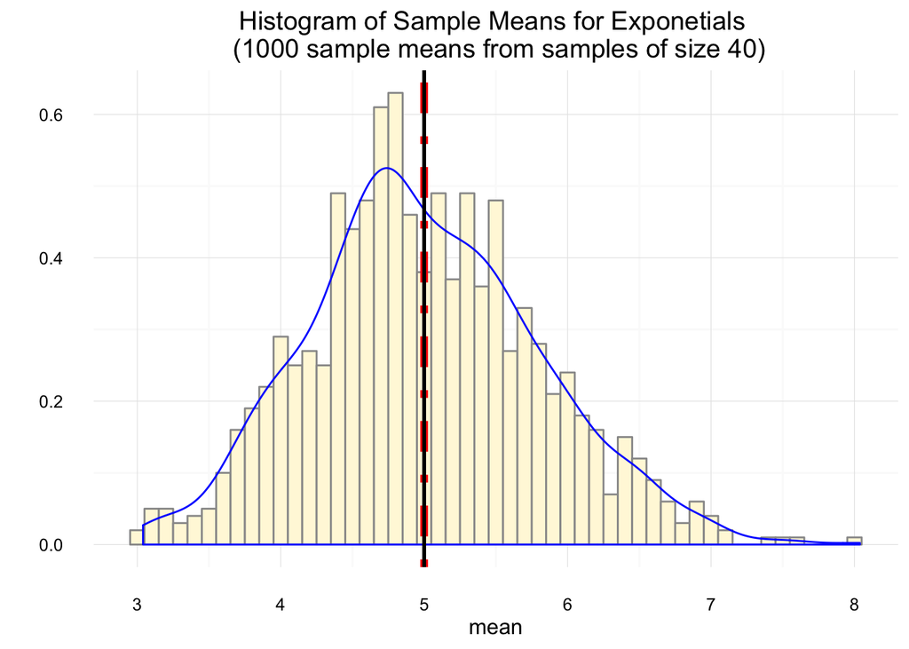

## Sample variance and theorectical variance

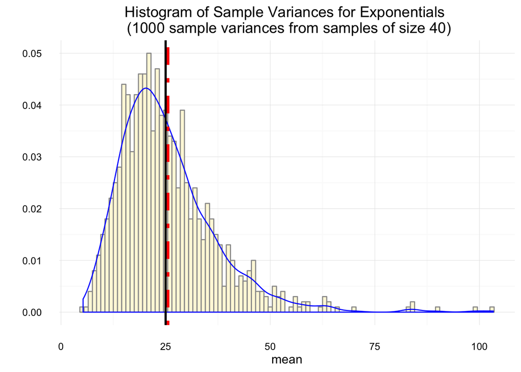

The sample mean is 5.  
The population mean is 5